# Spatial Data in R

## Spatial data

Lots of data in our field(s) are inherently spatial

R has lots of tools for interacting with and analyzing spatial data

## the `sp` package

The `sp` package is the workhorse of spatial mapping and analysis in R.

It defines spatial classes (e.g. `SpatialPoints`, `SpatialPointsDataFrame`) that make it possible to work with spatial data.

## actual spatial data versus coordinates

We often just have coordinate data, but this works differently in R from fully spatial data

```r
myCoords <- data.frame(long = runif(20, min=35, max=36), lat = runif(20, min = 3, max=5))
plot(myCoords)
```

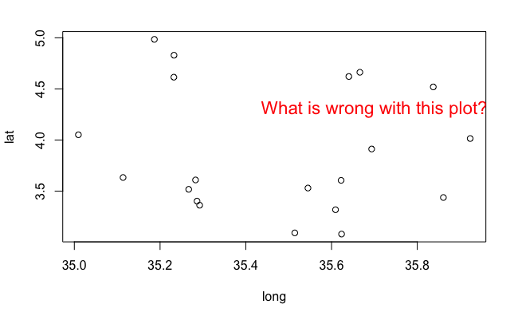

## making spatial objects

You can use the `SpatialPoints()` function to make your coordinates into a fully spatial object

**Warning**: This function will assume that your columns are in the order: X coordinate, Y Coordinate

For a gold star: Which is the x and which is the y when we are dealing with latitude and longitude?

```r
library(sp)
spCoords <- SpatialPoints(coords = coords)
```

Now there are a plethora of spatial things you can do with these points that you couldn’t before

```r
bbox(spMyCoords)
```

[output not shown]

## making spatial objects

[figure not shown]

## maps

The `maps` package provides basic maps that can serve as a backdrop to your points

```r
library(maps)
world <- map(database = "world")
```

[output not shown]

## maps

```r
USA <- map(database="USA")
```

```
Error in get(dbname) : object 'USAMapEnv' not found
```

## maps

```r
kenya <- map(database = "world", region="Kenya")
```

[output not shown]

## Challenge

Plot the `spCoords` points as solid blue filled circles on top of the Kenya map

## RGoogleMaps

```r
library("RgoogleMaps")
GW <- GetMap(center = c(38.899, -77.049), zoom = 17)
PlotOnStaticMap(GW)
```

[output not shown]

## RGoogleMaps

```r
GWSatellite <- GetMap(center = c(38.899, -77.049), zoom = 17, maptype = "satellite")
PlotOnStaticMap(GWSatellite, lon=-77.0493, lat=38.899, pch=16, col="red", cex=2)
```

[output not shown]

## Challenge

Get a satellite image of Africa, and plot a blue + symbol on Khartoum

## GIS in R

You can do almost anything in R that you can do in ArcGIS.

This is accomplished through additional packages, notably `rgdal` which is an R interface to the Geospatial Data Abstraction Library (GDAL), which is a great piece of open source software for spatial analysis. GDAL is the brains behind QGIS.

The `spatstats` package also implements a variety of spatial statitics.